# Risk Factor Analysis

## Outcome Variable

**Outcome Variable:** wast_rec90d

## Predictor Variables

**Intervention Variable:** nrooms

**Adjustment Set:**

- arm
- sex
- W_mage
- meducyrs
- feducyrs
- hhwealth_quart
- hfoodsec
- W_mhtcm
- W_nchldlt5
- W_parity
- impfloor
- impsan
- safeh20
- delta_W_mage
- delta_meducyrs
- delta_feducyrs
- delta_hhwealth_quart
- delta_hfoodsec
- delta_W_mhtcm
- delta_W_nchldlt5
- delta_W_parity
- delta_impfloor
- delta_impsan
- delta_safeh20

## Stratifying Variables

The analysis was stratified on these variable(s):

- agecat
- studyid
- country

## Data Summary

| agecat | studyid | country | nrooms | wast_rec90d | n_cell | n |
| --- | --- | --- | --- | --- | --- | --- |
| 0-24 months | ki0047075b-MAL-ED | BANGLADESH | 1 | 0 | 32 | 121 |
| 0-24 months | ki0047075b-MAL-ED | BANGLADESH | 1 | 1 | 61 | 121 |
| 0-24 months | ki0047075b-MAL-ED | BANGLADESH | 2 | 0 | 7 | 121 |
| 0-24 months | ki0047075b-MAL-ED | BANGLADESH | 2 | 1 | 9 | 121 |
| 0-24 months | ki0047075b-MAL-ED | BANGLADESH | 3 | 0 | 2 | 121 |
| 0-24 months | ki0047075b-MAL-ED | BANGLADESH | 3 | 1 | 6 | 121 |
| 0-24 months | ki0047075b-MAL-ED | BANGLADESH | 4+ | 0 | 3 | 121 |
| 0-24 months | ki0047075b-MAL-ED | BANGLADESH | 4+ | 1 | 1 | 121 |
| 0-24 months | ki0047075b-MAL-ED | BRAZIL | 1 | 0 | 0 | 23 |
| 0-24 months | ki0047075b-MAL-ED | BRAZIL | 1 | 1 | 0 | 23 |
| 0-24 months | ki0047075b-MAL-ED | BRAZIL | 2 | 0 | 0 | 23 |
| 0-24 months | ki0047075b-MAL-ED | BRAZIL | 2 | 1 | 2 | 23 |
| 0-24 months | ki0047075b-MAL-ED | BRAZIL | 3 | 0 | 1 | 23 |
| 0-24 months | ki0047075b-MAL-ED | BRAZIL | 3 | 1 | 3 | 23 |
| 0-24 months | ki0047075b-MAL-ED | BRAZIL | 4+ | 0 | 5 | 23 |
| 0-24 months | ki0047075b-MAL-ED | BRAZIL | 4+ | 1 | 12 | 23 |
| 0-24 months | ki0047075b-MAL-ED | INDIA | 1 | 0 | 27 | 173 |
| 0-24 months | ki0047075b-MAL-ED | INDIA | 1 | 1 | 38 | 173 |
| 0-24 months | ki0047075b-MAL-ED | INDIA | 2 | 0 | 23 | 173 |
| 0-24 months | ki0047075b-MAL-ED | INDIA | 2 | 1 | 41 | 173 |
| 0-24 months | ki0047075b-MAL-ED | INDIA | 3 | 0 | 14 | 173 |
| 0-24 months | ki0047075b-MAL-ED | INDIA | 3 | 1 | 18 | 173 |
| 0-24 months | ki0047075b-MAL-ED | INDIA | 4+ | 0 | 3 | 173 |
| 0-24 months | ki0047075b-MAL-ED | INDIA | 4+ | 1 | 9 | 173 |
| 0-24 months | ki0047075b-MAL-ED | NEPAL | 1 | 0 | 4 | 92 |
| 0-24 months | ki0047075b-MAL-ED | NEPAL | 1 | 1 | 23 | 92 |
| 0-24 months | ki0047075b-MAL-ED | NEPAL | 2 | 0 | 1 | 92 |
| 0-24 months | ki0047075b-MAL-ED | NEPAL | 2 | 1 | 5 | 92 |
| 0-24 months | ki0047075b-MAL-ED | NEPAL | 3 | 0 | 0 | 92 |
| 0-24 months | ki0047075b-MAL-ED | NEPAL | 3 | 1 | 6 | 92 |

[output cut: 354 more lines]

The following strata were considered:

- agecat: 0-24 months, studyid: ki0047075b-MAL-ED, country: BANGLADESH
- agecat: 0-24 months, studyid: ki0047075b-MAL-ED, country: BRAZIL
- agecat: 0-24 months, studyid: ki0047075b-MAL-ED, country: INDIA
- agecat: 0-24 months, studyid: ki0047075b-MAL-ED, country: NEPAL
- agecat: 0-24 months, studyid: ki0047075b-MAL-ED, country: PERU
- agecat: 0-24 months, studyid: ki0047075b-MAL-ED, country: SOUTH AFRICA
- agecat: 0-24 months, studyid: ki0047075b-MAL-ED, country: TANZANIA, UNITED REPUBLIC OF
- agecat: 0-24 months, studyid: ki1000108-CMC-V-BCS-2002, country: INDIA
- agecat: 0-24 months, studyid: ki1000108-IRC, country: INDIA
- agecat: 0-24 months, studyid: ki1017093b-PROVIDE, country: BANGLADESH
- agecat: 0-24 months, studyid: ki1017093c-NIH-Crypto, country: BANGLADESH
- agecat: 0-24 months, studyid: ki1113344-GMS-Nepal, country: NEPAL
- agecat: 0-24 months, studyid: ki1114097-CONTENT, country: PERU
- agecat: 0-24 months, studyid: ki1135781-COHORTS, country: INDIA
- agecat: 0-24 months, studyid: kiGH5241-JiVitA-3, country: BANGLADESH
- agecat: 0-24 months, studyid: kiGH5241-JiVitA-4, country: BANGLADESH
- agecat: 0-6 months, studyid: ki0047075b-MAL-ED, country: BANGLADESH
- agecat: 0-6 months, studyid: ki0047075b-MAL-ED, country: BRAZIL
- agecat: 0-6 months, studyid: ki0047075b-MAL-ED, country: INDIA
- agecat: 0-6 months, studyid: ki0047075b-MAL-ED, country: NEPAL
- agecat: 0-6 months, studyid: ki0047075b-MAL-ED, country: PERU
- agecat: 0-6 months, studyid: ki0047075b-MAL-ED, country: SOUTH AFRICA
- agecat: 0-6 months, studyid: ki0047075b-MAL-ED, country: TANZANIA, UNITED REPUBLIC OF
- agecat: 0-6 months, studyid: ki1000108-CMC-V-BCS-2002, country: INDIA
- agecat: 0-6 months, studyid: ki1000108-IRC, country: INDIA
- agecat: 0-6 months, studyid: ki1017093b-PROVIDE, country: BANGLADESH
- agecat: 0-6 months, studyid: ki1017093c-NIH-Crypto, country: BANGLADESH
- agecat: 0-6 months, studyid: ki1113344-GMS-Nepal, country: NEPAL
- agecat: 0-6 months, studyid: ki1114097-CONTENT, country: PERU
- agecat: 0-6 months, studyid: ki1135781-COHORTS, country: INDIA
- agecat: 0-6 months, studyid: kiGH5241-JiVitA-3, country: BANGLADESH
- agecat: 0-6 months, studyid: kiGH5241-JiVitA-4, country: BANGLADESH
- agecat: 6-24 months, studyid: ki0047075b-MAL-ED, country: BANGLADESH
- agecat: 6-24 months, studyid: ki0047075b-MAL-ED, country: BRAZIL
- agecat: 6-24 months, studyid: ki0047075b-MAL-ED, country: INDIA
- agecat: 6-24 months, studyid: ki0047075b-MAL-ED, country: NEPAL
- agecat: 6-24 months, studyid: ki0047075b-MAL-ED, country: PERU
- agecat: 6-24 months, studyid: ki0047075b-MAL-ED, country: SOUTH AFRICA
- agecat: 6-24 months, studyid: ki0047075b-MAL-ED, country: TANZANIA, UNITED REPUBLIC OF
- agecat: 6-24 months, studyid: ki1000108-CMC-V-BCS-2002, country: INDIA
- agecat: 6-24 months, studyid: ki1000108-IRC, country: INDIA
- agecat: 6-24 months, studyid: ki1017093b-PROVIDE, country: BANGLADESH
- agecat: 6-24 months, studyid: ki1017093c-NIH-Crypto, country: BANGLADESH
- agecat: 6-24 months, studyid: ki1113344-GMS-Nepal, country: NEPAL
- agecat: 6-24 months, studyid: ki1114097-CONTENT, country: PERU
- agecat: 6-24 months, studyid: ki1135781-COHORTS, country: INDIA
- agecat: 6-24 months, studyid: kiGH5241-JiVitA-3, country: BANGLADESH
- agecat: 6-24 months, studyid: kiGH5241-JiVitA-4, country: BANGLADESH

### Dropped Strata

Some strata were dropped due to rare outcomes:

- agecat: 0-24 months, studyid: ki0047075b-MAL-ED, country: BANGLADESH
- agecat: 0-24 months, studyid: ki0047075b-MAL-ED, country: BRAZIL
- agecat: 0-24 months, studyid: ki0047075b-MAL-ED, country: INDIA
- agecat: 0-24 months, studyid: ki0047075b-MAL-ED, country: NEPAL
- agecat: 0-24 months, studyid: ki0047075b-MAL-ED, country: PERU
- agecat: 0-24 months, studyid: ki0047075b-MAL-ED, country: SOUTH AFRICA
- agecat: 0-24 months, studyid: ki0047075b-MAL-ED, country: TANZANIA, UNITED REPUBLIC OF
- agecat: 0-24 months, studyid: ki1000108-CMC-V-BCS-2002, country: INDIA
- agecat: 0-24 months, studyid: ki1017093b-PROVIDE, country: BANGLADESH
- agecat: 0-24 months, studyid: ki1114097-CONTENT, country: PERU
- agecat: 0-24 months, studyid: ki1135781-COHORTS, country: INDIA
- agecat: 0-6 months, studyid: ki0047075b-MAL-ED, country: BANGLADESH
- agecat: 0-6 months, studyid: ki0047075b-MAL-ED, country: BRAZIL
- agecat: 0-6 months, studyid: ki0047075b-MAL-ED, country: INDIA
- agecat: 0-6 months, studyid: ki0047075b-MAL-ED, country: NEPAL
- agecat: 0-6 months, studyid: ki0047075b-MAL-ED, country: PERU
- agecat: 0-6 months, studyid: ki0047075b-MAL-ED, country: SOUTH AFRICA
- agecat: 0-6 months, studyid: ki0047075b-MAL-ED, country: TANZANIA, UNITED REPUBLIC OF
- agecat: 0-6 months, studyid: ki1000108-CMC-V-BCS-2002, country: INDIA
- agecat: 0-6 months, studyid: ki1000108-IRC, country: INDIA
- agecat: 0-6 months, studyid: ki1017093b-PROVIDE, country: BANGLADESH
- agecat: 0-6 months, studyid: ki1017093c-NIH-Crypto, country: BANGLADESH
- agecat: 0-6 months, studyid: ki1114097-CONTENT, country: PERU
- agecat: 0-6 months, studyid: ki1135781-COHORTS, country: INDIA
- agecat: 6-24 months, studyid: ki0047075b-MAL-ED, country: BANGLADESH
- agecat: 6-24 months, studyid: ki0047075b-MAL-ED, country: BRAZIL
- agecat: 6-24 months, studyid: ki0047075b-MAL-ED, country: INDIA
- agecat: 6-24 months, studyid: ki0047075b-MAL-ED, country: NEPAL
- agecat: 6-24 months, studyid: ki0047075b-MAL-ED, country: PERU
- agecat: 6-24 months, studyid: ki0047075b-MAL-ED, country: SOUTH AFRICA
- agecat: 6-24 months, studyid: ki0047075b-MAL-ED, country: TANZANIA, UNITED REPUBLIC OF
- agecat: 6-24 months, studyid: ki1000108-CMC-V-BCS-2002, country: INDIA
- agecat: 6-24 months, studyid: ki1000108-IRC, country: INDIA
- agecat: 6-24 months, studyid: ki1017093b-PROVIDE, country: BANGLADESH
- agecat: 6-24 months, studyid: ki1017093c-NIH-Crypto, country: BANGLADESH
- agecat: 6-24 months, studyid: ki1114097-CONTENT, country: PERU
- agecat: 6-24 months, studyid: ki1135781-COHORTS, country: INDIA
- agecat: 6-24 months, studyid: kiGH5241-JiVitA-3, country: BANGLADESH

## Methods Detail

We’re interested in the causal parameters $E[Y_a]$ for all values of $a \in \mathcal{A}$. These parameters represent the mean outcome if, possibly contrary to fact, we intervened to set all units to have $A=a$. Under the randomization and positivity assumptions, these are identified by the statistical parameters $\psi_a=E_W[E_{Y|A,W}(Y|A=a,W)]$. In addition, we’re interested in the mean of $Y$, $E[Y]$ under no intervention (the observed mean). We will estimate these parameters by using SuperLearner to fit the relevant likelihood factors – $E_{Y|A,W}(Y|A=a,W)$ and $p(A=a|W)$, and then updating our likelihood fit using a joint TMLE.

For unadjusted analyses ($W=\{\}$), initial likelihoods were estimated using Lrnr_glm to estimate the simple $E(Y|A)$ and Lrnr_mean to estimate $p(A)$. For adjusted analyses, a small library containing Lrnr_glmnet, Lrnr_xgboost, and Lrnr_mean was used.

Having estimated these parameters, we will then use the delta method to estimate relative risks and attributable risks relative to a prespecified baseline level of $A$.

# Results Detail

## Results Plots

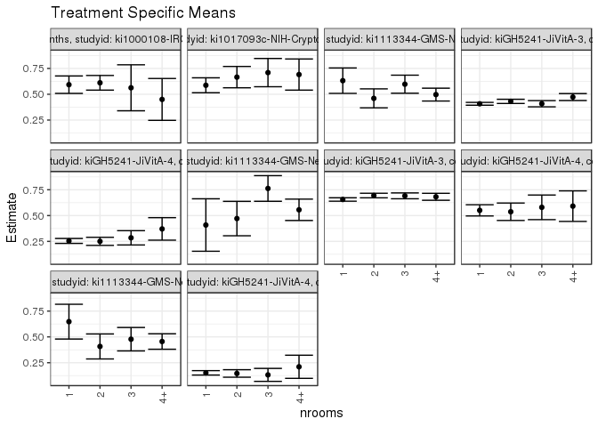

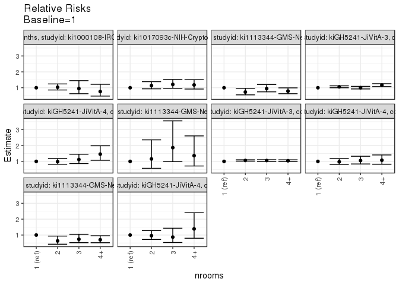

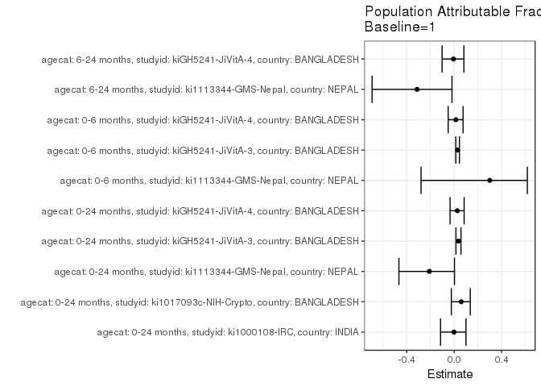

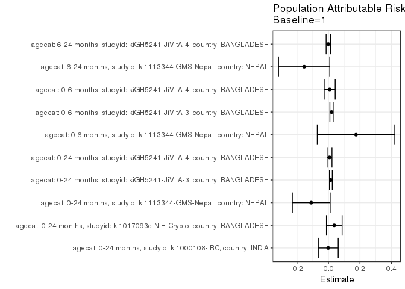

## Results Table

### Parameter: TSM

| agecat | studyid | country | intervention_level | baseline_level | estimate | ci_lower | ci_upper |
| --- | --- | --- | --- | --- | --- | --- | --- |
| 0-24 months | ki1000108-IRC | INDIA | 1 | NA | 0.5925926 | 0.5081592 | 0.6770260 |
| 0-24 months | ki1000108-IRC | INDIA | 2 | NA | 0.6111111 | 0.5401543 | 0.6820679 |
| 0-24 months | ki1000108-IRC | INDIA | 3 | NA | 0.5625000 | 0.3398407 | 0.7851593 |
| 0-24 months | ki1000108-IRC | INDIA | 4+ | NA | 0.4500000 | 0.2471890 | 0.6528110 |
| 0-24 months | ki1017093c-NIH-Crypto | BANGLADESH | 1 | NA | 0.5868916 | 0.5145233 | 0.6592599 |
| 0-24 months | ki1017093c-NIH-Crypto | BANGLADESH | 2 | NA | 0.6658164 | 0.5623307 | 0.7693021 |
| 0-24 months | ki1017093c-NIH-Crypto | BANGLADESH | 3 | NA | 0.7096105 | 0.5727585 | 0.8464624 |
| 0-24 months | ki1017093c-NIH-Crypto | BANGLADESH | 4+ | NA | 0.6907126 | 0.5398783 | 0.8415470 |
| 0-24 months | ki1113344-GMS-Nepal | NEPAL | 1 | NA | 0.6314308 | 0.5083406 | 0.7545211 |
| 0-24 months | ki1113344-GMS-Nepal | NEPAL | 2 | NA | 0.4601515 | 0.3683478 | 0.5519551 |
| 0-24 months | ki1113344-GMS-Nepal | NEPAL | 3 | NA | 0.5973303 | 0.5098908 | 0.6847699 |
| 0-24 months | ki1113344-GMS-Nepal | NEPAL | 4+ | NA | 0.4965517 | 0.4344351 | 0.5586683 |
| 0-24 months | kiGH5241-JiVitA-3 | BANGLADESH | 1 | NA | 0.4074899 | 0.3937612 | 0.4212187 |
| 0-24 months | kiGH5241-JiVitA-3 | BANGLADESH | 2 | NA | 0.4311266 | 0.4109217 | 0.4513316 |
| 0-24 months | kiGH5241-JiVitA-3 | BANGLADESH | 3 | NA | 0.4081949 | 0.3780746 | 0.4383152 |
| 0-24 months | kiGH5241-JiVitA-3 | BANGLADESH | 4+ | NA | 0.4728102 | 0.4392087 | 0.5064116 |
| 0-24 months | kiGH5241-JiVitA-4 | BANGLADESH | 1 | NA | 0.2544000 | 0.2306160 | 0.2781840 |
| 0-24 months | kiGH5241-JiVitA-4 | BANGLADESH | 2 | NA | 0.2502523 | 0.2112209 | 0.2892837 |
| 0-24 months | kiGH5241-JiVitA-4 | BANGLADESH | 3 | NA | 0.2845745 | 0.2152607 | 0.3538883 |
| 0-24 months | kiGH5241-JiVitA-4 | BANGLADESH | 4+ | NA | 0.3707865 | 0.2617648 | 0.4798082 |
| 0-6 months | ki1113344-GMS-Nepal | NEPAL | 1 | NA | 0.4084350 | 0.1543243 | 0.6625456 |
| 0-6 months | ki1113344-GMS-Nepal | NEPAL | 2 | NA | 0.4712243 | 0.3045536 | 0.6378950 |
| 0-6 months | ki1113344-GMS-Nepal | NEPAL | 3 | NA | 0.7626976 | 0.6385016 | 0.8868935 |
| 0-6 months | ki1113344-GMS-Nepal | NEPAL | 4+ | NA | 0.5558634 | 0.4523265 | 0.6594004 |
| 0-6 months | kiGH5241-JiVitA-3 | BANGLADESH | 1 | NA | 0.6558797 | 0.6394706 | 0.6722887 |
| 0-6 months | kiGH5241-JiVitA-3 | BANGLADESH | 2 | NA | 0.6941443 | 0.6719719 | 0.7163167 |
| 0-6 months | kiGH5241-JiVitA-3 | BANGLADESH | 3 | NA | 0.6911805 | 0.6629364 | 0.7194246 |
| 0-6 months | kiGH5241-JiVitA-3 | BANGLADESH | 4+ | NA | 0.6818863 | 0.6482575 | 0.7155151 |
| 0-6 months | kiGH5241-JiVitA-4 | BANGLADESH | 1 | NA | 0.5505173 | 0.4961089 | 0.6049257 |
| 0-6 months | kiGH5241-JiVitA-4 | BANGLADESH | 2 | NA | 0.5371021 | 0.4525287 | 0.6216756 |
| 0-6 months | kiGH5241-JiVitA-4 | BANGLADESH | 3 | NA | 0.5798064 | 0.4604870 | 0.6991257 |
| 0-6 months | kiGH5241-JiVitA-4 | BANGLADESH | 4+ | NA | 0.5913946 | 0.4434279 | 0.7393613 |
| 6-24 months | ki1113344-GMS-Nepal | NEPAL | 1 | NA | 0.6476971 | 0.4792204 | 0.8161739 |
| 6-24 months | ki1113344-GMS-Nepal | NEPAL | 2 | NA | 0.4075329 | 0.2864372 | 0.5286286 |
| 6-24 months | ki1113344-GMS-Nepal | NEPAL | 3 | NA | 0.4777915 | 0.3643672 | 0.5912158 |
| 6-24 months | ki1113344-GMS-Nepal | NEPAL | 4+ | NA | 0.4553649 | 0.3803551 | 0.5303747 |
| 6-24 months | kiGH5241-JiVitA-4 | BANGLADESH | 1 | NA | 0.1517761 | 0.1303785 | 0.1731737 |
| 6-24 months | kiGH5241-JiVitA-4 | BANGLADESH | 2 | NA | 0.1458047 | 0.1093596 | 0.1822498 |
| 6-24 months | kiGH5241-JiVitA-4 | BANGLADESH | 3 | NA | 0.1320000 | 0.0691088 | 0.1948912 |
| 6-24 months | kiGH5241-JiVitA-4 | BANGLADESH | 4+ | NA | 0.2105263 | 0.0986019 | 0.3224507 |

### Parameter: E(Y)

| agecat | studyid | country | intervention_level | baseline_level | estimate | ci_lower | ci_upper |
| --- | --- | --- | --- | --- | --- | --- | --- |
| 0-24 months | ki1000108-IRC | INDIA | NA | NA | 0.5913706 | 0.5391835 | 0.6435576 |
| 0-24 months | ki1017093c-NIH-Crypto | BANGLADESH | NA | NA | 0.6237942 | 0.5698223 | 0.6777662 |
| 0-24 months | ki1113344-GMS-Nepal | NEPAL | NA | NA | 0.5222816 | 0.4773852 | 0.5671781 |
| 0-24 months | kiGH5241-JiVitA-3 | BANGLADESH | NA | NA | 0.4228277 | 0.4116994 | 0.4339560 |
| 0-24 months | kiGH5241-JiVitA-4 | BANGLADESH | NA | NA | 0.2613103 | 0.2419607 | 0.2806599 |
| 0-6 months | ki1113344-GMS-Nepal | NEPAL | NA | NA | 0.5833333 | 0.5108676 | 0.6557991 |
| 0-6 months | kiGH5241-JiVitA-3 | BANGLADESH | NA | NA | 0.6754701 | 0.6621313 | 0.6888089 |
| 0-6 months | kiGH5241-JiVitA-4 | BANGLADESH | NA | NA | 0.5583942 | 0.5167799 | 0.6000084 |
| 6-24 months | ki1113344-GMS-Nepal | NEPAL | NA | NA | 0.4934383 | 0.4388573 | 0.5480193 |
| 6-24 months | kiGH5241-JiVitA-4 | BANGLADESH | NA | NA | 0.1508986 | 0.1332882 | 0.1685090 |

### Parameter: RR

| agecat | studyid | country | intervention_level | baseline_level | estimate | ci_lower | ci_upper |
| --- | --- | --- | --- | --- | --- | --- | --- |
| 0-24 months | ki1000108-IRC | INDIA | 1 | 1 | 1.0000000 | 1.0000000 | 1.0000000 |
| 0-24 months | ki1000108-IRC | INDIA | 2 | 1 | 1.0312500 | 0.8580769 | 1.2393722 |
| 0-24 months | ki1000108-IRC | INDIA | 3 | 1 | 0.9492188 | 0.6232698 | 1.4456279 |
| 0-24 months | ki1000108-IRC | INDIA | 4+ | 1 | 0.7593750 | 0.4733474 | 1.2182394 |
| 0-24 months | ki1017093c-NIH-Crypto | BANGLADESH | 1 | 1 | 1.0000000 | 1.0000000 | 1.0000000 |
| 0-24 months | ki1017093c-NIH-Crypto | BANGLADESH | 2 | 1 | 1.1344793 | 0.9315661 | 1.3815910 |
| 0-24 months | ki1017093c-NIH-Crypto | BANGLADESH | 3 | 1 | 1.2090998 | 0.9633007 | 1.5176178 |
| 0-24 months | ki1017093c-NIH-Crypto | BANGLADESH | 4+ | 1 | 1.1768999 | 0.9182687 | 1.5083747 |
| 0-24 months | ki1113344-GMS-Nepal | NEPAL | 1 | 1 | 1.0000000 | 1.0000000 | 1.0000000 |
| 0-24 months | ki1113344-GMS-Nepal | NEPAL | 2 | 1 | 0.7287441 | 0.5512235 | 0.9634349 |
| 0-24 months | ki1113344-GMS-Nepal | NEPAL | 3 | 1 | 0.9459949 | 0.7412151 | 1.2073505 |
| 0-24 months | ki1113344-GMS-Nepal | NEPAL | 4+ | 1 | 0.7863913 | 0.6237221 | 0.9914853 |
| 0-24 months | kiGH5241-JiVitA-3 | BANGLADESH | 1 | 1 | 1.0000000 | 1.0000000 | 1.0000000 |
| 0-24 months | kiGH5241-JiVitA-3 | BANGLADESH | 2 | 1 | 1.0580056 | 0.9992660 | 1.1201981 |
| 0-24 months | kiGH5241-JiVitA-3 | BANGLADESH | 3 | 1 | 1.0017301 | 0.9240374 | 1.0859551 |
| 0-24 months | kiGH5241-JiVitA-3 | BANGLADESH | 4+ | 1 | 1.1602990 | 1.0728478 | 1.2548787 |
| 0-24 months | kiGH5241-JiVitA-4 | BANGLADESH | 1 | 1 | 1.0000000 | 1.0000000 | 1.0000000 |
| 0-24 months | kiGH5241-JiVitA-4 | BANGLADESH | 2 | 1 | 0.9836960 | 0.8201119 | 1.1799096 |
| 0-24 months | kiGH5241-JiVitA-4 | BANGLADESH | 3 | 1 | 1.1186103 | 0.8617552 | 1.4520238 |
| 0-24 months | kiGH5241-JiVitA-4 | BANGLADESH | 4+ | 1 | 1.4574942 | 1.0705777 | 1.9842457 |
| 0-6 months | ki1113344-GMS-Nepal | NEPAL | 1 | 1 | 1.0000000 | 1.0000000 | 1.0000000 |
| 0-6 months | ki1113344-GMS-Nepal | NEPAL | 2 | 1 | 1.1537315 | 0.5648423 | 2.3565808 |
| 0-6 months | ki1113344-GMS-Nepal | NEPAL | 3 | 1 | 1.8673659 | 0.9816769 | 3.5521418 |
| 0-6 months | ki1113344-GMS-Nepal | NEPAL | 4+ | 1 | 1.3609594 | 0.7110239 | 2.6049904 |
| 0-6 months | kiGH5241-JiVitA-3 | BANGLADESH | 1 | 1 | 1.0000000 | 1.0000000 | 1.0000000 |
| 0-6 months | kiGH5241-JiVitA-3 | BANGLADESH | 2 | 1 | 1.0583409 | 1.0167485 | 1.1016347 |
| 0-6 months | kiGH5241-JiVitA-3 | BANGLADESH | 3 | 1 | 1.0538221 | 1.0050721 | 1.1049367 |
| 0-6 months | kiGH5241-JiVitA-3 | BANGLADESH | 4+ | 1 | 1.0396515 | 0.9841871 | 1.0982416 |
| 0-6 months | kiGH5241-JiVitA-4 | BANGLADESH | 1 | 1 | 1.0000000 | 1.0000000 | 1.0000000 |
| 0-6 months | kiGH5241-JiVitA-4 | BANGLADESH | 2 | 1 | 0.9756318 | 0.8101411 | 1.1749279 |
| 0-6 months | kiGH5241-JiVitA-4 | BANGLADESH | 3 | 1 | 1.0532029 | 0.8380727 | 1.3235561 |
| 0-6 months | kiGH5241-JiVitA-4 | BANGLADESH | 4+ | 1 | 1.0742526 | 0.8208468 | 1.4058878 |
| 6-24 months | ki1113344-GMS-Nepal | NEPAL | 1 | 1 | 1.0000000 | 1.0000000 | 1.0000000 |
| 6-24 months | ki1113344-GMS-Nepal | NEPAL | 2 | 1 | 0.6292029 | 0.4238719 | 0.9339997 |
| 6-24 months | ki1113344-GMS-Nepal | NEPAL | 3 | 1 | 0.7376774 | 0.5187196 | 1.0490598 |
| 6-24 months | ki1113344-GMS-Nepal | NEPAL | 4+ | 1 | 0.7030521 | 0.5165432 | 0.9569041 |
| 6-24 months | kiGH5241-JiVitA-4 | BANGLADESH | 1 | 1 | 1.0000000 | 1.0000000 | 1.0000000 |
| 6-24 months | kiGH5241-JiVitA-4 | BANGLADESH | 2 | 1 | 0.9606563 | 0.7209765 | 1.2800148 |
| 6-24 months | kiGH5241-JiVitA-4 | BANGLADESH | 3 | 1 | 0.8697021 | 0.5291699 | 1.4293742 |
| 6-24 months | kiGH5241-JiVitA-4 | BANGLADESH | 4+ | 1 | 1.3870847 | 0.8002791 | 2.4041662 |

### Parameter: PAR

| agecat | studyid | country | intervention_level | baseline_level | estimate | ci_lower | ci_upper |
| --- | --- | --- | --- | --- | --- | --- | --- |
| 0-24 months | ki1000108-IRC | INDIA | 1 | NA | -0.0012220 | -0.0643943 | 0.0619503 |
| 0-24 months | ki1017093c-NIH-Crypto | BANGLADESH | 1 | NA | 0.0369026 | -0.0127652 | 0.0865704 |
| 0-24 months | ki1113344-GMS-Nepal | NEPAL | 1 | NA | -0.1091492 | -0.2292367 | 0.0109383 |
| 0-24 months | kiGH5241-JiVitA-3 | BANGLADESH | 1 | NA | 0.0153377 | 0.0063335 | 0.0243420 |
| 0-24 months | kiGH5241-JiVitA-4 | BANGLADESH | 1 | NA | 0.0069103 | -0.0085964 | 0.0224169 |
| 0-6 months | ki1113344-GMS-Nepal | NEPAL | 1 | NA | 0.1748984 | -0.0709679 | 0.4207646 |
| 0-6 months | kiGH5241-JiVitA-3 | BANGLADESH | 1 | NA | 0.0195904 | 0.0092127 | 0.0299682 |
| 0-6 months | kiGH5241-JiVitA-4 | BANGLADESH | 1 | NA | 0.0078769 | -0.0270876 | 0.0428414 |
| 6-24 months | ki1113344-GMS-Nepal | NEPAL | 1 | NA | -0.1542588 | -0.3167916 | 0.0082740 |
| 6-24 months | kiGH5241-JiVitA-4 | BANGLADESH | 1 | NA | -0.0008775 | -0.0147036 | 0.0129486 |

### Parameter: PAF

| agecat | studyid | country | intervention_level | baseline_level | estimate | ci_lower | ci_upper |
| --- | --- | --- | --- | --- | --- | --- | --- |
| 0-24 months | ki1000108-IRC | INDIA | 1 | NA | -0.0020664 | -0.1147791 | 0.0992501 |
| 0-24 months | ki1017093c-NIH-Crypto | BANGLADESH | 1 | NA | 0.0591583 | -0.0239608 | 0.1355303 |
| 0-24 months | ki1113344-GMS-Nepal | NEPAL | 1 | NA | -0.2089853 | -0.4656548 | 0.0027356 |
| 0-24 months | kiGH5241-JiVitA-3 | BANGLADESH | 1 | NA | 0.0362742 | 0.0148001 | 0.0572803 |
| 0-24 months | kiGH5241-JiVitA-4 | BANGLADESH | 1 | NA | 0.0264447 | -0.0346067 | 0.0838934 |
| 0-6 months | ki1113344-GMS-Nepal | NEPAL | 1 | NA | 0.2998258 | -0.2791679 | 0.6167477 |
| 0-6 months | kiGH5241-JiVitA-3 | BANGLADESH | 1 | NA | 0.0290027 | 0.0135403 | 0.0442226 |
| 0-6 months | kiGH5241-JiVitA-4 | BANGLADESH | 1 | NA | 0.0141063 | -0.0505527 | 0.0747857 |
| 6-24 months | ki1113344-GMS-Nepal | NEPAL | 1 | NA | -0.3126203 | -0.6918681 | -0.0183843 |
| 6-24 months | kiGH5241-JiVitA-4 | BANGLADESH | 1 | NA | -0.0058151 | -0.1018119 | 0.0818178 |